# SIBER Analysis of Coral Physiology

Peter Flood and Serena Hackerott

2/8/2024

# Setup

### Load Packages

```r
##Install Packages if Needed
if (!require("ggplot2")) install.packages("ggplot2")
if (!require("cowplot")) install.packages("cowplot")
if (!require("SIBER")) install.packages("SIBER")
if (!require("vegan")) install.packages("vegan")
if (!require("Hmisc")) install.packages("Hmisc")
if (!require("corrplot")) install.packages("corrplot")
if (!require("tidyverse")) install.packages("tidyverse")
if (!require("Rmisc")) install.packages("Rmisc")
if (!require("ggpubr")) install.packages("ggpubr")
if (!require("lme4")) install.packages("lme4")
if (!require("lmerTest")) install.packages("lmerTest")
if (!require("DHARMa")) install.packages("DHARMa")
if (!require("emmeans")) install.packages("emmeans")
if (!require("effectsize")) install.packages("effectsize")
##Load Packages
library(ggplot2) #Required for ggplots
library(cowplot) #Required for plotting panel figures
library(SIBER) #Required for generating physiological ellipses and percent overlap calculations
library(vegan) #Required for NMDS
library(Hmisc) #Required for correlations
library(corrplot) #Required for correlation plot
library(tidyverse) #Required for data manipulation
library(Rmisc) #Required for data summary
library(ggpubr) #Required for stat_conf_ellipse
library(lme4) #Required for mixed effects models
library(lmerTest) #Required for significance in mixed effects models
library(DHARMa) #Required to check residuals of mixed effects models
library(emmeans) #Required for pairwise comparisons
library(effectsize) #Required for eta_squared effect sizes
```

# Sample Data and Metadata

### Load and Organize Data

```r
##Load Data
#Note: Physiological metrics calculated in 02_PhysiologyMetrics.R file
Phys<-read.csv("Outputs/CoralData.csv", header=TRUE)

##Set factor variables
Phys$TimeP<-factor(Phys$TimeP, levels=c("TP1", "TP2", "TP3", "TP4"))
Phys$Site<-factor(Phys$Site, levels=c("KL", "SS"))
Phys$Genotype<-factor(Phys$Genotype, levels=c("AC8", "AC10", "AC12"))
Phys$Orig<-factor(Phys$Orig, levels=c("N", "T"))
Phys$Origin<-factor(Phys$Origin, levels=c("Native", "Transplant"))
Phys$Site.Orig<-factor(Phys$Site.Orig, levels=c("KL.N", "KL.T", "SS.N", "SS.T"))

##Set rownames
rownames(Phys)<-Phys$ID

##Load Environmental Data
#Note: Averaged environmental metrics calculated in 01_ExperimentalSetup.R file
Env<-read.csv("Outputs/AvgEnvData.csv", header=TRUE)
Env$TimeP<-factor(Env$TimeP, levels=c("TP1", "TP2", "TP3", "TP4"))
Env$Site<-factor(Env$Site, levels=c("KL", "SS"))
```

# SIBER Ellipses

### Prepare Input Data

#### NMDS Ordination

SIBER runs on a two dimensional data set. So first, we need to reduce the dimensionality of the physiology data. We’re going to do this via Non-Metric Multidimensional Scaling (NMDS) on the scaled physiological metrics of interest.

```r
##Remove NA's
Phys.rm<-na.omit(Phys)

##Standardize Variables for similar scales
Phys.St <- Phys.rm %>% mutate_at(c("TP_ug.cm2", "AFDW_mg.cm2", "Chl_ug.cm2"), ~(scale(.) %>% as.vector))

#Select only the physiology columns of interest (without covariates) to put into the NMDS
names(Phys.St)
```

```
 [1] "RandN"       "ID"          "TimeP"       "Site"        "Genotype"    "Orig"
 [7] "Origin"      "Set"         "Site.Orig"   "SA_cm2"      "TP_ug.cm2"   "AFDW_mg.cm2"
[13] "Chl_ug.cm2"
```

```r
phys.num <- Phys.St[,c(11:13)]

#Run NMDS
phys.nmds <- metaMDS(phys.num, distance = "euclidean", k = 2, autotransform = F)
```

```
'comm' has negative data: 'autotransform', 'noshare' and 'wascores' set to FALSE
```

```
*** Best solution repeated 1 times
```

```
species scores not available
```

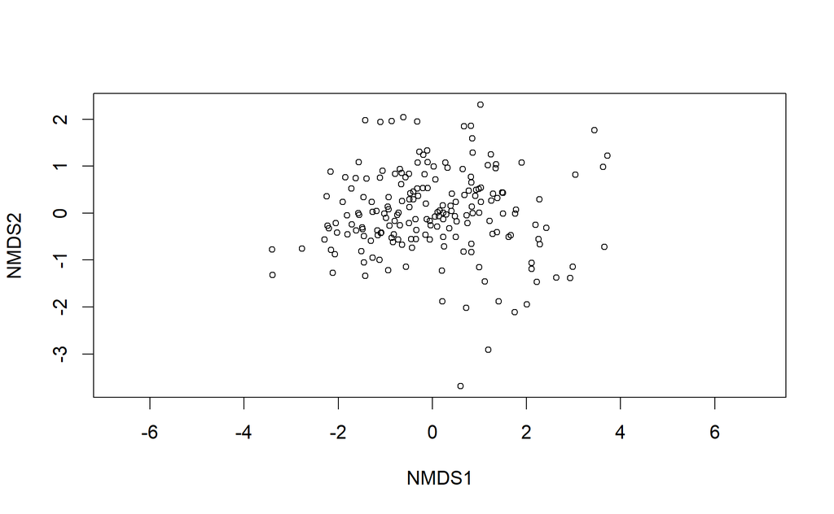

```r
#Quick plot of NMDS output
plot(phys.nmds)
```

#### NMDS Model

```r
##Correlation with Physiology Metrics
phys.envi.fit <- envfit(phys.nmds, phys.num)
phys.envi.fit
```

```
***VECTORS

               NMDS1    NMDS2     r2 Pr(>r)
TP_ug.cm2    0.68338  0.73006 0.9089  0.001 ***
AFDW_mg.cm2  0.99464  0.10344 0.8053  0.001 ***
Chl_ug.cm2   0.58126 -0.81372 0.9022  0.001 ***
---
Signif. codes:  0 ‘***’ 0.001 ‘**’ 0.01 ‘*’ 0.05 ‘.’ 0.1 ‘ ’ 1
Permutation: free
Number of permutations: 999
```

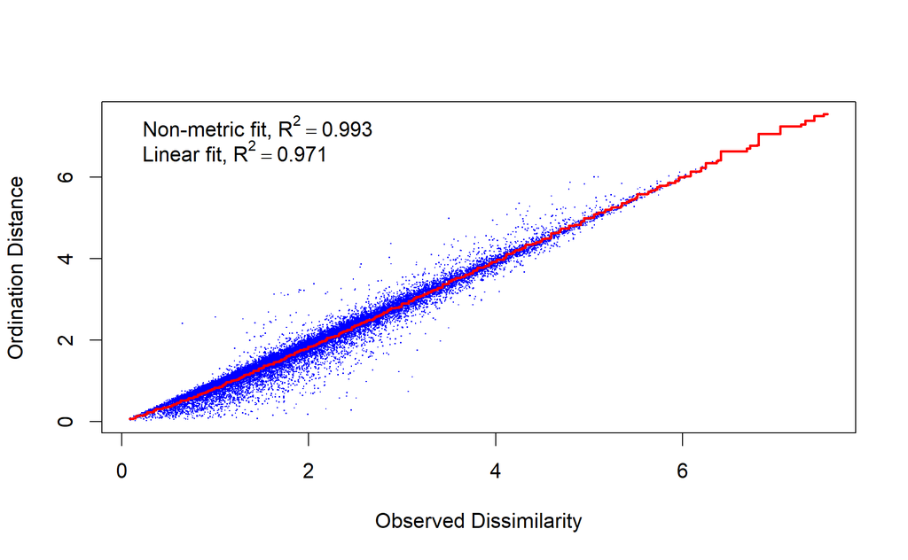

```r
phys.envi.vectors <- phys.envi.fit[["vectors"]][["arrows"]]

##Check Stress
stressplot(phys.nmds)
```

```r
NMDS.stress<- sprintf("Stress = %.2f", phys.nmds$stress)
NMDS.stress
```

```
[1] "Stress = 0.09"
```

```r
#Prepare for Plotting
phys.nmds.samples.plot.data <- cbind(phys.num, phys.nmds$points)
phys.nmds.samples.plot.data$ID<-rownames(phys.nmds.samples.plot.data)
phys.nmds.samples.plot.data<-merge(phys.nmds.samples.plot.data, Phys.rm[,c(1:9)])
phys.nmds.samples.plot.data$Geno.Orig<-paste(phys.nmds.samples.plot.data$Genotype, phys.nmds.samples.plot.data$Orig, sep=".")
phys.nmds.samples.plot.data$Geno.Orig<-factor(phys.nmds.samples.plot.data$Geno.Orig, levels=c("AC8.N","AC8.T", "AC10.N", "AC10.T", "AC12.N", "AC12.T"), ordered=TRUE)

phys.nmds.covariates.plot.data <- data.frame(phys.envi.vectors)
phys.nmds.covariates.plot.data$Covariate<-c(rownames(phys.envi.vectors))
names(phys.nmds.covariates.plot.data)[1:2]<-c("MDS1", "MDS2")
phys.nmds.covariates.plot.data$Covariate
```

```
[1] "TP_ug.cm2"   "AFDW_mg.cm2" "Chl_ug.cm2"
```

```r
phys.nmds.covariates.plot.data$Metric<-c("Protein", "Biomass", "Chlorophyll")
```

#### Plot NMDS

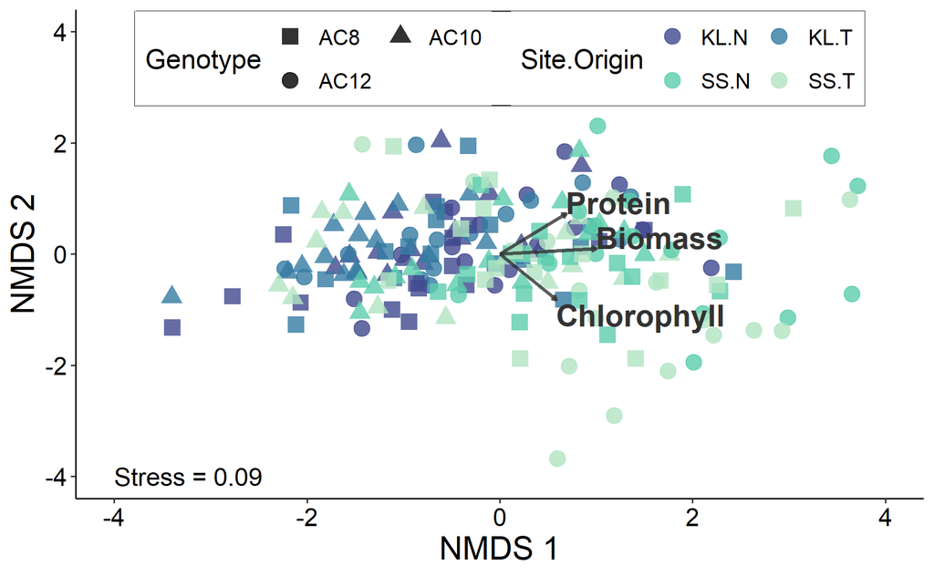

```r
phys.nmds.plot<-ggplot(data = phys.nmds.samples.plot.data, aes(x = MDS1, y = MDS2)) +
  geom_point(data = phys.nmds.samples.plot.data, aes(colour = Site.Orig, shape=Genotype), size = point.sz, alpha = 0.8) +
  scale_colour_manual(values =Orig.colors.o)+
  scale_shape_manual(values=Geno.shapes.o)+
  theme_classic()+
  scale_x_continuous(limits = c(-4, 4))+
  scale_y_continuous(limits = c(-4, 4))+
   theme(axis.title.x = element_text(size = axis.title.sz),
        axis.title.y = element_text(size = axis.title.sz),
        axis.text.x=element_text(size=axis.txt.sz, colour="black"),
        axis.text.y=element_text(size=axis.txt.sz, colour="black"),
        legend.text=element_text(size=leg.txt.sz),
        legend.title=element_text(size=leg.title.sz),
        legend.box.background = element_rect(color = "black"),
         legend.position=c(0.5, .9),
        legend.direction="horizontal",
         legend.box = "horizontal")+
  geom_segment(aes(x = 0, y = 0, xend = MDS1, yend = MDS2),
               data = phys.nmds.covariates.plot.data,
               linewidth =bar.sz, alpha = 0.8, colour = "grey20",
               arrow=arrow(length=unit(0.01,"npc"))) +
  geom_text(data=phys.nmds.covariates.plot.data,
            aes(x=MDS1, y=MDS2, label=Metric, fontface = "bold",
                hjust=0.15*(1-sign(MDS1)),vjust=0.6*(1-sign(MDS2))),
            colour = "grey20", size=levels.sz-1)+
  labs(x="NMDS 1", y="NMDS 2", color="Site.Origin")+
  guides(color=guide_legend(nrow=2, byrow=TRUE), shape=guide_legend(nrow=2, byrow=TRUE)) +
  annotate("text", x = -4, y = -4, label = NMDS.stress, hjust=0, size=sig.sz); phys.nmds.plot
```

#### Data Prep for SIBER

```r
#Prepare data to be input into SIBER
phys.siber.input <- phys.nmds$points %>% #extract 2-D physiology axes from NMDS
  bind_cols(#add back covariates from original phys data
    select(Phys.log, ID:Site.Orig) #select those covariate columns
  ) %>%
  #SIBER object needs four specific columns
  #iso1, iso2, group, and community
  #Need to manipulate the data to match that format
  #create  group variable that combines site, genotype and origin
  unite("group", c(Site, Genotype, Orig), sep = "_") %>%
  #rename variables to match names for SIBER
  dplyr::rename(community = TimeP, iso1 = MDS1, iso2 = MDS2) %>%
  #retain only columns for SIBER
  select(iso1, iso2, group, community)
```

### Run SIBER

Grouping by each genotype at each site, timepoint, and from each origin

```r
# create SIBER object
phys.siber.object <- createSiberObject(phys.siber.input)
# sample sizes by group
phys.siber.object[["sample.sizes"]]
```

```
    KL_AC10_N KL_AC10_T KL_AC12_N KL_AC12_T KL_AC8_N KL_AC8_T SS_AC10_N SS_AC10_T
TP1         4         4         4         4        4        4         4         4
TP2         4         4         4         4        4        4         4         4
TP3         4         4         4         4        4        4         4         4
TP4         4         4         4         4        4        3         4         4
    SS_AC12_N SS_AC12_T SS_AC8_N SS_AC8_T
TP1         4         4        4        4
TP2         4         4        4        4
TP3         4         4        4        4
TP4         4         4        4        3
```

```r
# Calculate sumamry statistics for each group: TA, SEA and SEAc
group.ML <- groupMetricsML(phys.siber.object)
print(group.ML)
```

```
     TP1.KL_AC10_N TP1.KL_AC10_T TP1.KL_AC12_N TP1.KL_AC12_T TP1.KL_AC8_N TP1.KL_AC8_T
TA       0.3913939      1.443577     0.2979201     0.6282738    0.4414975     2.190079
SEA      0.4888719      1.801543     0.3438535     0.7878781    0.5193928     2.779380
SEAc     0.7333078      2.702315     0.5157802     1.1818171    0.7790892     4.169070
     TP1.SS_AC10_N TP1.SS_AC10_T TP1.SS_AC12_N TP1.SS_AC12_T TP1.SS_AC8_N TP1.SS_AC8_T
TA      0.05963310      1.283409     0.8381160      2.041365    0.5497568     4.641606
SEA     0.07718126      1.681978     0.9123043      2.595700    0.7515970     6.117096
SEAc    0.11577188      2.522967     1.3684564      3.893550    1.1273956     9.175644
     TP2.KL_AC10_N TP2.KL_AC10_T TP2.KL_AC12_N TP2.KL_AC12_T TP2.KL_AC8_N TP2.KL_AC8_T
TA       0.3902521      3.078950     0.1986996     0.5623006    0.1192264    0.9894463
SEA      0.4978634      3.976995     0.2468515     0.7272734    0.1251003    1.1098889
SEAc     0.7467951      5.965493     0.3702773     1.0909101    0.1876505    1.6648333
     TP2.SS_AC10_N TP2.SS_AC10_T TP2.SS_AC12_N TP2.SS_AC12_T TP2.SS_AC8_N TP2.SS_AC8_T
TA        1.143707     0.7160748      5.230542     0.6017328     1.561271     1.369288
SEA       1.510667     0.8606407      6.060534     0.8315238     1.854937     1.574380
SEAc      2.266001     1.2909611      9.090801     1.2472858     2.782406     2.361569
     TP3.KL_AC10_N TP3.KL_AC10_T TP3.KL_AC12_N TP3.KL_AC12_T TP3.KL_AC8_N TP3.KL_AC8_T
TA       0.2364421     0.4060282     0.9185325      1.098926     1.636782     1.179605
SEA      0.2740072     0.5129269     1.0861003      1.286105     1.886691     1.451775
SEAc     0.4110108     0.7693904     1.6291505      1.929158     2.830037     2.177663
     TP3.SS_AC10_N TP3.SS_AC10_T TP3.SS_AC12_N TP3.SS_AC12_T TP3.SS_AC8_N TP3.SS_AC8_T
TA       0.6059972     0.9827552      1.582958     0.4505310    0.8503918    0.7456595
SEA      0.7737399     1.2522311      2.178802     0.4802016    1.0720646    0.8858889
SEAc     1.1606098     1.8783467      3.268203     0.7203024    1.6080969    1.3288333
     TP4.KL_AC10_N TP4.KL_AC10_T TP4.KL_AC12_N TP4.KL_AC12_T TP4.KL_AC8_N TP4.KL_AC8_T
TA        1.852650      1.329370     0.4818280     0.2556371     1.501188     3.867303
SEA       2.137369      1.664675     0.6342851     0.2766656     1.967413     7.014511
SEAc      3.206054      2.497012     0.9514277     0.4149984     2.951119    14.029022
     TP4.SS_AC10_N TP4.SS_AC10_T TP4.SS_AC12_N TP4.SS_AC12_T TP4.SS_AC8_N TP4.SS_AC8_T
TA       0.8566572      3.136163     0.6361705     0.3405193     2.229668    0.1090976
SEA      1.0783145      3.851849     0.8440811     0.4118714     2.516358    0.1978812
SEAc     1.6174717      5.777773     1.2661216     0.6178071     3.774537    0.3957623
```

```r
##Save SIBER Object in Outputs
save(phys.siber.object, file="Outputs/SIBER/Phys.SIBER.Object.RData")
```

# Ellipse Overlap

### Calculate Percent Overlap

Calculating the overlap of physiological niche space between corals of the same genotype, at the same site and timepoint. Using Percent of Niche Overlap as a more informative indicator of how similar the Transplant corals are to their Native clonemates.

First, calculating the area of the 95% prediction ellipses for each group as well as the maximum likelihood of overlap between physiological niche ellipses.

#### Calculate Niche Areas

```r
##Load SIBER Object
load("Outputs/SIBER/Phys.SIBER.Object.RData")

##Dataframe of Niche Overlap
Niches<-data.frame(rbind(
  #KL AC10
  maxLikOverlap("TP1.KL_AC10_N", "TP1.KL_AC10_T", phys.siber.object, p = 0.95, n = 360),
  maxLikOverlap("TP2.KL_AC10_N", "TP2.KL_AC10_T", phys.siber.object, p = 0.95, n = 360),
  maxLikOverlap("TP3.KL_AC10_N", "TP3.KL_AC10_T", phys.siber.object, p = 0.95, n = 360),
  maxLikOverlap("TP4.KL_AC10_N", "TP4.KL_AC10_T", phys.siber.object, p = 0.95, n = 360),
  #KL AC12
  maxLikOverlap("TP1.KL_AC12_N", "TP1.KL_AC12_T", phys.siber.object, p = 0.95, n = 360),
  maxLikOverlap("TP2.KL_AC12_N", "TP2.KL_AC12_T", phys.siber.object, p = 0.95, n = 360),
  maxLikOverlap("TP3.KL_AC12_N", "TP3.KL_AC12_T", phys.siber.object, p = 0.95, n = 360),
  maxLikOverlap("TP4.KL_AC12_N", "TP4.KL_AC12_T", phys.siber.object, p = 0.95, n = 360),
  #KL AC8
  maxLikOverlap("TP1.KL_AC8_N", "TP1.KL_AC8_T", phys.siber.object, p = 0.95, n = 360),
  maxLikOverlap("TP2.KL_AC8_N", "TP2.KL_AC8_T", phys.siber.object, p = 0.95, n = 360),
  maxLikOverlap("TP3.KL_AC8_N", "TP3.KL_AC8_T", phys.siber.object, p = 0.95, n = 360),
  maxLikOverlap("TP4.KL_AC8_N", "TP4.KL_AC8_T", phys.siber.object, p = 0.95, n = 360),
  #SS AC10
  maxLikOverlap("TP1.SS_AC10_N", "TP1.SS_AC10_T", phys.siber.object, p = 0.95, n = 360),
  maxLikOverlap("TP2.SS_AC10_N", "TP2.SS_AC10_T", phys.siber.object, p = 0.95, n = 360),
  maxLikOverlap("TP3.SS_AC10_N", "TP3.SS_AC10_T", phys.siber.object, p = 0.95, n = 360),
  maxLikOverlap("TP4.SS_AC10_N", "TP4.SS_AC10_T", phys.siber.object, p = 0.95, n = 360),
  #SS AC12
  maxLikOverlap("TP1.SS_AC12_N", "TP1.SS_AC12_T", phys.siber.object, p = 0.95, n = 360),
  maxLikOverlap("TP2.SS_AC12_N", "TP2.SS_AC12_T", phys.siber.object, p = 0.95, n = 360),
  maxLikOverlap("TP3.SS_AC12_N", "TP3.SS_AC12_T", phys.siber.object, p = 0.95, n = 360),
  maxLikOverlap("TP4.SS_AC12_N", "TP4.SS_AC12_T", phys.siber.object, p = 0.95, n = 360),
  #SS AC8
  maxLikOverlap("TP1.SS_AC8_N", "TP1.SS_AC8_T", phys.siber.object, p = 0.95, n = 360),
  maxLikOverlap("TP2.SS_AC8_N", "TP2.SS_AC8_T", phys.siber.object, p = 0.95, n = 360),
  maxLikOverlap("TP3.SS_AC8_N", "TP3.SS_AC8_T", phys.siber.object, p = 0.95, n = 360),
  maxLikOverlap("TP4.SS_AC8_N", "TP4.SS_AC8_T", phys.siber.object, p = 0.95, n = 360)
  ))

names(Niches)<-c("Native", "Transplant", "Overlap")
Niches$Site<-c(rep("KL", 12), rep("SS", 12))
Niches$Genotype<-c(rep(c(rep("AC10",4), rep("AC12",4), rep("AC8",4)),2))
Niches$TimeP<-rep(c("TP1", "TP2", "TP3", "TP4"),6)
```

#### Calculate Overlap

Proportion of niche overlap = Area of overlap between Native and Transplant physiological niches / Area of the Transplant niche

Proportion of the Transplant Niche area that is overlapping with that of the “expected” Native niche (if there was no lasting effect of Origin)

```r
##Proportion of Transplant Niche Area that is overlapping with Native niche
Niches$pOverlap<-Niches$Overlap/Niches$Transplant

##Write out dataframe
write.csv(Niches, "Outputs/SIBER/SIBER_p.Overlap.csv", row.names=FALSE)

##Read in
Niches<-read.csv("Outputs/SIBER/SIBER_p.Overlap.csv", header=TRUE)

##Set factor variables
Niches$Site<-factor(Niches$Site, levels=c("KL", "SS"))
Niches$Genotype<-factor(Niches$Genotype, levels=c("AC8", "AC10", "AC12"))
Niches$TimeP<-factor(Niches$TimeP)

##Add Months Post-Transplant
Niches$Time<-ifelse(Niches$TimeP=="TP1", 1, ifelse(Niches$TimeP=="TP2", 4,
            ifelse(Niches$TimeP=="TP3", 8, ifelse(Niches$TimeP=="TP4", 12, NA))))
```

### Differences in Overlap

#### Across Time and Space

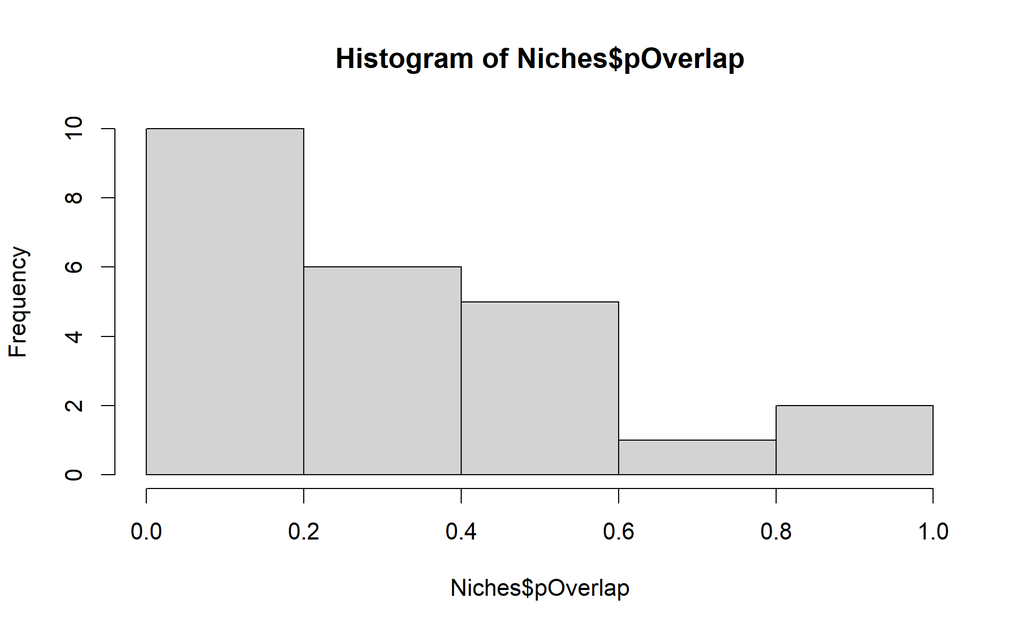

```r
##Check Normality
hist(Niches$pOverlap)
```

```r
shapiro.test(Niches$pOverlap)
```

```
    Shapiro-Wilk normality test

data:  Niches$pOverlap
W = 0.87797, p-value = 0.007567
```

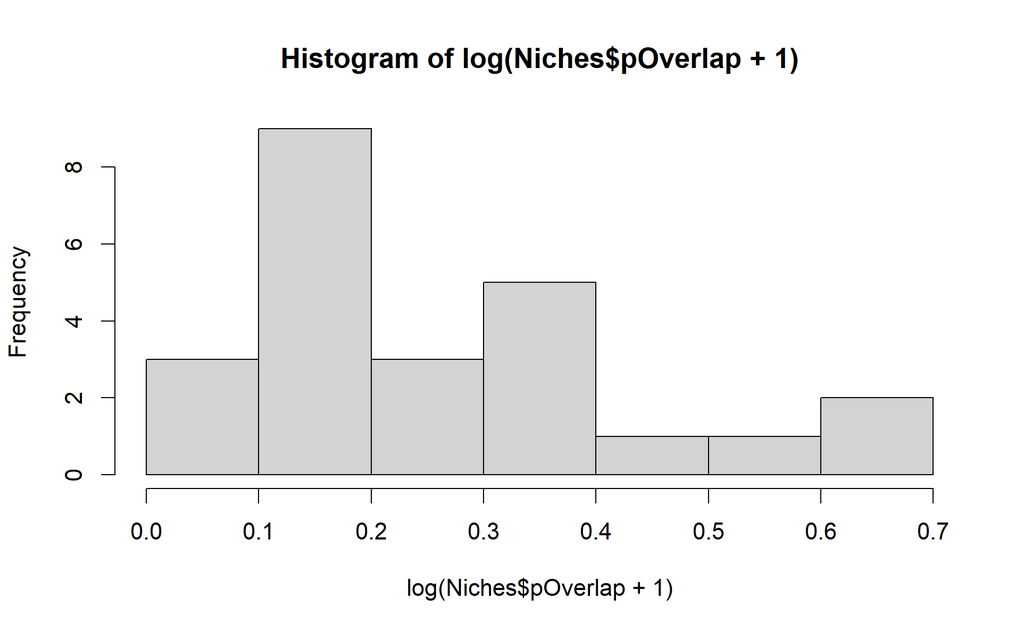

```r
#Not Normal

hist(log(Niches$pOverlap+1))
```

```r
shapiro.test(log(Niches$pOverlap+1))
```

```
    Shapiro-Wilk normality test

data:  log(Niches$pOverlap + 1)
W = 0.92574, p-value = 0.07831
```

```r
#Normal

#Model with log(+1) transformation
##Model Overlap as a function of Site and Time, with Genotype as a Random effect
#Interaction between Site and Time
Overlap.lme<-lmer(log(pOverlap+1)~Time*Site+(1|Genotype), data=Niches)
```

```
boundary (singular) fit: see help('isSingular')
```

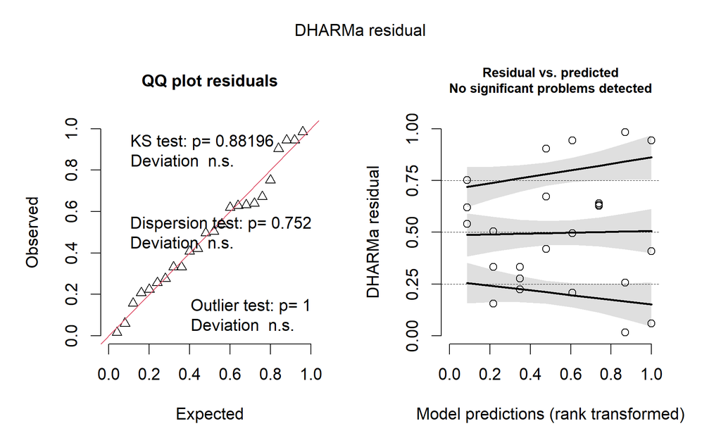

```r
##Check residuals
Overlap.lme_res <- simulateResiduals(fittedModel = Overlap.lme, plot = F)
plot(Overlap.lme_res)
```

```r
##Model results
summary(Overlap.lme)
```

```
Linear mixed model fit by REML. t-tests use Satterthwaite's method ['lmerModLmerTest']
Formula: log(pOverlap + 1) ~ Time * Site + (1 | Genotype)
   Data: Niches

REML criterion at convergence: 3.1

Scaled residuals:
     Min       1Q   Median       3Q      Max
-1.97373 -0.55986  0.02339  0.44265  1.94713

Random effects:
 Groups   Name        Variance Std.Dev.
 Genotype (Intercept) 0.00000  0.0000
 Residual             0.03125  0.1768
Number of obs: 24, groups:  Genotype, 3

Fixed effects:
            Estimate Std. Error       df t value Pr(>|t|)
(Intercept)  0.09483    0.09232 20.00000   1.027   0.3166
Time         0.02685    0.01231 20.00000   2.181   0.0413 *
SiteSS       0.08240    0.13056 20.00000   0.631   0.5351
Time:SiteSS -0.01254    0.01741 20.00000  -0.720   0.4796
---
Signif. codes:  0 ‘***’ 0.001 ‘**’ 0.01 ‘*’ 0.05 ‘.’ 0.1 ‘ ’ 1

Correlation of Fixed Effects:
            (Intr) Time   SiteSS
Time        -0.833
SiteSS      -0.707  0.589
Time:SiteSS  0.589 -0.707 -0.833
optimizer (nloptwrap) convergence code: 0 (OK)
boundary (singular) fit: see help('isSingular')
```

```r
eta_squared(Overlap.lme)
```

```
# Effect Size for ANOVA (Type III)

Parameter | Eta2 (partial) |       95% CI
-----------------------------------------
Time      |           0.22 | [0.01, 1.00]
Site      |           0.02 | [0.00, 1.00]
Time:Site |           0.03 | [0.00, 1.00]

- One-sided CIs: upper bound fixed at [1.00].
```

```r
##Save results
Overlap.res<-data.frame(summary(Overlap.lme)$coefficients[-1,])
Overlap.res$Predictor<-c("Time", "Site", "Time x Site")
Overlap.res$EtaSq<-c(eta_squared(Overlap.lme)$Eta2)
Overlap.res$Response<-rep("Niche Overlap", nrow(Overlap.res))
Overlap.res<-Overlap.res %>% dplyr::rename(SE = Std..Error, DF = df, t = t.value, p =Pr...t..)
```

### Plot Overlap over Time

```r
##Update Proportion to Percent for Axis
Niches$percOverlap<-round((Niches$pOverlap*100), 2)

##Summary statistics by Site and Origin
pOverlap.orig.sum<-summarySE(Niches, measurevar="percOverlap", groupvars=c("Time"), na.rm=TRUE)

pOverlap.orig.sum
```

| Time | N | percOverlap | sd | se | ci |
| --- | --- | --- | --- | --- | --- |
| 1 | 6 | 15.50167 | 8.14961 | 3.327064 | 8.552491 |
| 4 | 6 | 25.14333 | 19.98272 | 8.157913 | 20.970583 |
| 8 | 6 | 42.82833 | 18.95719 | 7.739242 | 19.894354 |
| 12 | 6 | 47.09000 | 41.40420 | 16.903193 | 43.451041 |

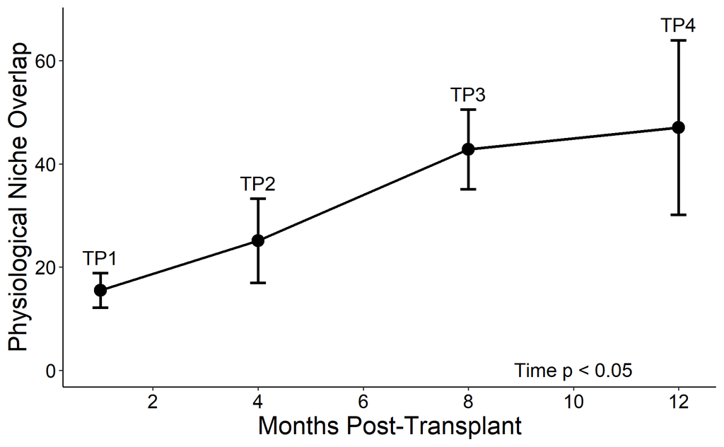

```r
##Plot Average Niche Overlap across Timepoints
Overlap_Avg.plot<-ggplot(pOverlap.orig.sum, aes(x=Time, y=percOverlap, group=1)) +
  scale_colour_manual(values=Site.colors.o)+
  geom_errorbar(aes(ymin=percOverlap-se, ymax=percOverlap+se), width=cap.sz, linewidth=bar.sz) +
  geom_path(linewidth=bar.sz)+
  geom_point(size=point.sz)+
  theme_classic()+
  theme(axis.title.x = element_text(size = axis.title.sz),
        axis.title.y = element_text(size = axis.title.sz),
        axis.text.x=element_text(size=axis.txt.sz, colour="black"),
        axis.text.y=element_text(size=axis.txt.sz, colour="black"),
        legend.position="none",
        strip.text=element_text(size=axis.title.sz))+
  scale_x_continuous(breaks = seq(0, 12, by = 2))+
  labs(x="Months Post-Transplant", y="Physiological Niche Overlap")+
  geom_text(aes(x=Time, y=percOverlap+se+3), label=c("TP1", "TP2", "TP3", "TP4"), size=sig.sz)+
  annotate("text", x=10, y=0.1, label="Time p < 0.05", size=sig.sz); Overlap_Avg.plot
```

# Environment and Physiology

### Merge Environmental and Physiology Data

```r
PhysEnv<-merge(Phys.rm, Env)

##Standardize Explanatory Environmental Variables for similar scales
PhysEnv.St <- PhysEnv %>% mutate_at(c("Temp.a", "Cond.a", "Temp.sd", "Cond.sd", "PAR.a", "Sat.hr", "TN_uM", "TP_uM", "N.P", "DIN_uM"), ~(scale(.) %>% as.vector))

##Set rownames
rownames(PhysEnv.St)<-PhysEnv.St$ID
```

### Distance Based RDA

```r
##dbRDA
PhysEnv.rda<-dbrda(vegdist(PhysEnv.St[, c(11:13)], "euclidean") ~ Temp.a + Cond.a +
                         Temp.sd + Cond.sd + Sat.hr + N.P + DIN_uM,
                       data=PhysEnv.St, dist="euclidean")

##Check model significance
anova(PhysEnv.rda)
```

```
Permutation test for dbrda under reduced model
Permutation: free
Number of permutations: 999

Model: dbrda(formula = vegdist(PhysEnv.St[, c(11:13)], "euclidean") ~ Temp.a + Cond.a + Temp.sd + Cond.sd + Sat.hr + N.P + DIN_uM, data = PhysEnv.St, distance = "euclidean")
          Df Variance      F Pr(>F)
Model      7     5384 11.036  0.001 ***
Residual 182    12684
---
Signif. codes:  0 ‘***’ 0.001 ‘**’ 0.01 ‘*’ 0.05 ‘.’ 0.1 ‘ ’ 1
```

```r
##Check variance explained by model
(summary(PhysEnv.rda)$constr.chi/summary(PhysEnv.rda)$tot.chi)*100
```

```
[1] 29.79853
```

```r
RsquareAdj(PhysEnv.rda)$adj.r.squared*100
```

```
[1] 27.09847
```

```r
##Check variance explained by each Environmental metric
anova.cca(PhysEnv.rda, by="terms")
```

```
Permutation test for dbrda under reduced model
Terms added sequentially (first to last)
Permutation: free
Number of permutations: 999

Model: dbrda(formula = vegdist(PhysEnv.St[, c(11:13)], "euclidean") ~ Temp.a + Cond.a + Temp.sd + Cond.sd + Sat.hr + N.P + DIN_uM, data = PhysEnv.St, distance = "euclidean")
          Df Variance       F Pr(>F)
Temp.a     1   1858.7 26.6702  0.001 ***
Cond.a     1    354.6  5.0887  0.025 *
Temp.sd    1     13.5  0.1944  0.670
Cond.sd    1    277.5  3.9822  0.042 *
Sat.hr     1    890.3 12.7754  0.001 ***
N.P        1      2.2  0.0320  0.868
DIN_uM     1   1987.0 28.5109  0.001 ***
Residual 182  12683.9
---
Signif. codes:  0 ‘***’ 0.001 ‘**’ 0.01 ‘*’ 0.05 ‘.’ 0.1 ‘ ’ 1
```

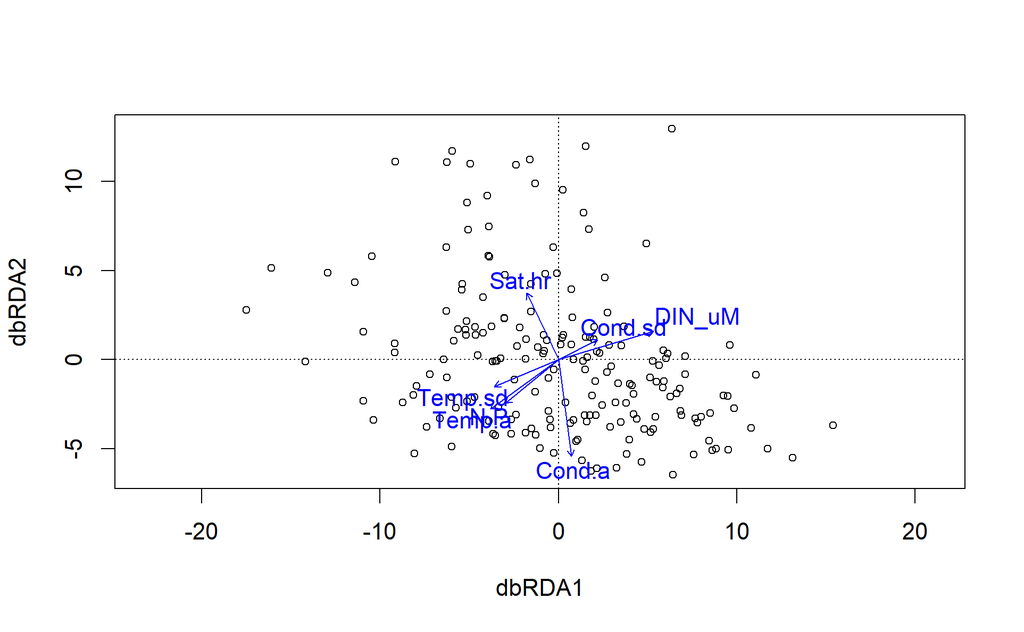

```r
##Save Variance Results
PhysEnv.res<-data.frame(anova.cca(PhysEnv.rda, by="terms")[-8,])
PhysEnv.res$Predictor<-rownames(PhysEnv.res)
PhysEnv.res$Metric<-c("Average Temperature", "Average Conductivity", "Temperature Std. Dev.",
                      "Conductivity Std. Dev.", "Hours Saturating Irradiance",
                      "Nitrogen:Phosphorus", "Dissolved Inorganic Nitrogen")
PhysEnv.res<-PhysEnv.res %>% dplyr::rename(DF = Df, p =Pr..F.)

##Quick dbRDA biplot
plot(PhysEnv.rda)
```

### RDA Plot

#### Prepare for Plotting

```r
##Samples
PhysEnv.rda.scores<- data.frame(scores(PhysEnv.rda)$sites)
PhysEnv.rda.scores$ID<- rownames(PhysEnv.rda.scores)
names(PhysEnv.St)
```

```
 [1] "TimeP"       "Site"        "RandN"       "ID"          "Genotype"    "Orig"
 [7] "Origin"      "Set"         "Site.Orig"   "SA_cm2"      "TP_ug.cm2"   "AFDW_mg.cm2"
[13] "Chl_ug.cm2"  "Temp.a"      "Cond.a"      "Temp.sd"     "Cond.sd"     "PAR.a"
[19] "Sat.hr"      "TN_uM"       "TP_uM"       "N.P"         "DIN_uM"
```

```r
PhysEnv.rda.scores<-merge(PhysEnv.St[,c(1:9)], PhysEnv.rda.scores)

##Environmental Parameters
PhysEnv.rda.env<-data.frame(scores(PhysEnv.rda)$biplot[,1:2]) * ordiArrowMul(PhysEnv.rda, display="bp", fill=7)
PhysEnv.rda.env$Variable<-rownames(PhysEnv.rda.env)
PhysEnv.rda.env$Variable
```

```
[1] "Temp.a"  "Cond.a"  "Temp.sd" "Cond.sd" "Sat.hr"  "N.P"     "DIN_uM"
```

```r
PhysEnv.rda.env$Metric<-c("Temperature", "Conductivity", "Temp SD", "Cond SD", "Sat PAR", "N:P", "DIN")

##Adjusted R2
RDA.adjr2<- sprintf("%1.2f", (RsquareAdj(PhysEnv.rda)$adj.r.squared*100))
RDA.adjr2
```

```
[1] "27.10"
```

#### Plot RDA

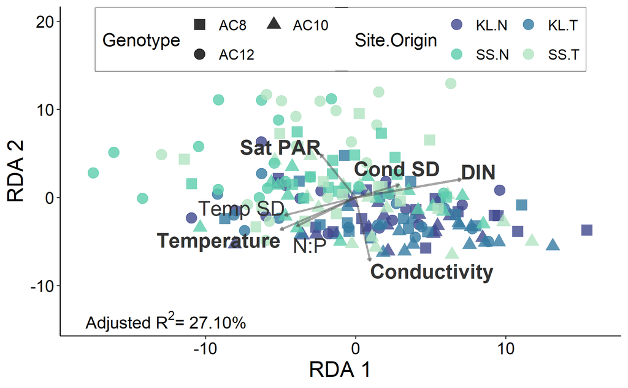

```r
phys.env.rda.plot<-ggplot(data = PhysEnv.rda.scores, aes(x = dbRDA1, y = dbRDA2)) +
  geom_point(data = PhysEnv.rda.scores, size = point.sz, alpha = 0.8, aes(colour = Site.Orig, shape=Genotype)) +
  theme_classic()+
  scale_colour_manual(values =Orig.colors.o)+
  scale_shape_manual(values=Geno.shapes.o)+
  theme(axis.title.x = element_text(size = axis.title.sz),
        axis.title.y = element_text(size = axis.title.sz),
        axis.text.x=element_text(size=axis.txt.sz, colour="black"),
        axis.text.y=element_text(size=axis.txt.sz, colour="black"),
        legend.text=element_text(size=leg.txt.sz),
        legend.title=element_text(size=leg.title.sz),
        legend.box.background = element_rect(color = "black"),
        legend.position=c(0.5, .9),
        legend.direction="horizontal",
         legend.box = "horizontal")+
  xlim(-18, 16)+
  ylim(-14, 20)+
  labs(x="RDA 1", y="RDA 2", color="Site.Origin")+
  geom_segment(aes(x = 0, y = 0, xend = dbRDA1, yend = dbRDA2),
               data = PhysEnv.rda.env, linewidth =bar.sz, alpha = 0.5, colour = "grey30",
               arrow=arrow(length=unit(0.01,"npc")))+
  geom_text(data = PhysEnv.rda.env[-c(3,6),],
            aes(x=c(dbRDA1[1:2], dbRDA1[3]-3, dbRDA1[4:5]),
                y = c(dbRDA2[1:2], dbRDA2[3]+1, dbRDA2[4:5]),
                label = Metric, fontface = "bold",
                hjust=0.5*(1-sign(dbRDA1)),vjust=0.6*(1-sign(dbRDA2))),
            colour = "grey20", size=levels.sz-1)+
  geom_text(data = PhysEnv.rda.env[c(3,6),],
            aes(x=c(dbRDA1[1], dbRDA1[2]+2), y = c(dbRDA2[1]+2, dbRDA2[2]-1),
                label = Metric, hjust=0.5*(1-sign(dbRDA1)),vjust=0.6*(1-sign(dbRDA2))),
            colour = "grey20", size=levels.sz-1)+
  guides(color=guide_legend(nrow=2, byrow=TRUE), shape=guide_legend(nrow=2, byrow=TRUE)) +
  annotate("text", x = -18, y = -14, label = expression(paste('Adjusted R'^2*"= 27.10%")), hjust=0, size=sig.sz); phys.env.rda.plot
```

```r
NA
```

# Figures

### Figure 2

```r
##Create Panel
PhysEnvNiche_fig<-plot_grid(phys.env.rda.plot, phys.nmds.plot, Overlap_Avg.plot,
                    rel_widths=1,
                    rel_heights = 1,
                    nrow=1, ncol=3, byrow=T,
                    labels = c("A", "B", "C"),
                    label_size=panel.lab.sz)
##Save Figure
ggsave(filename="Figures/02_Physiology/Fig2_PhysEnvNiches.png", plot=PhysEnvNiche_fig, dpi=300, width=20, height=6.5, units="in")
```

# Tables

### Table 1

```r
##Save Results
Table1_EnvPredictors<-PhysEnv.res

##Organize
Table1_EnvPredictors<-Table1_EnvPredictors[,c("Metric", "DF", "Variance", "F", "p")]

##Add Significance levels
Table1_EnvPredictors$Significance<-ifelse(Table1_EnvPredictors$p<0.001, "***",
                              ifelse(Table1_EnvPredictors$p<0.01, "**",
                                     ifelse(Table1_EnvPredictors$p<0.05, "*",
                                            ifelse(Table1_EnvPredictors$p<0.1, "-", ""))))
#Round to 3 digits
Table1_EnvPredictors$Variance<-round(Table1_EnvPredictors$Variance, 3)
Table1_EnvPredictors$F<-round(Table1_EnvPredictors$F, 3)

##Rename Predictor
Table1_EnvPredictors<-Table1_EnvPredictors %>% dplyr::rename(Predictor = Metric)

##Write Out Table
write.csv(Table1_EnvPredictors, "Tables/Table1_Physiology_Environment_RDA_Results.csv", row.names=FALSE)
```

### Table S3B Niche Overlap

```r
##Save Results
TableS3B_NicheOverlap<-Overlap.res

##Organize
TableS3B_NicheOverlap<-TableS3B_NicheOverlap[,c("Response", "Predictor", "Estimate", "SE", "DF", "t", "p", "EtaSq")]

#Round to 3 digits
TableS3B_NicheOverlap$Estimate<-round(TableS3B_NicheOverlap$Estimate, 3)
TableS3B_NicheOverlap$SE<-round(TableS3B_NicheOverlap$SE, 3)
TableS3B_NicheOverlap$t<-round(TableS3B_NicheOverlap$t, 3)
TableS3B_NicheOverlap$p<-round(TableS3B_NicheOverlap$p, 3)
TableS3B_NicheOverlap$EtaSq<-round(TableS3B_NicheOverlap$EtaSq, 3)

#Integer
TableS3B_NicheOverlap$DF<-round(TableS3B_NicheOverlap$DF, 0)

##Write Out Table
write.csv(TableS3B_NicheOverlap, "Tables/TableS3B_Niche_Overlap_Results.csv", row.names=FALSE)
```